# [ENSAE, 2A] Séminaire statistique 2023

Hassan Maissoro/ Léa Joly / Antoine Klein

2023-03-17

**Sujet : Modélisation de la production d’électricité d’un barrage**

Objectif : Prédire la production d’électricité pour le lendemain compte tenu de la production passée

# 1 On installe les packages

```r
install.packages("manipulateWidget")
install.packages("tseries")
install.packages("zoo")
install.packages("dygraphs")
install.packages('pls')
install.packages("forecast", dependencies = TRUE)# Pour établir des prédictions
install.packages("ggplot2") # Pour les plots
install.packages("fUnitRoots")# Tests de racine unitaire
```

# 2 On importe les packages

```r
library(data.table)
library(magrittr)
library(dygraphs)
library(manipulateWidget)
library(pls)
require(zoo) #format de serie temporelle pratique et facile d'utilisation
require(tseries) #diverses fonctions sur les series temporelles
library(forecast)
library(ggplot2)
library(fUnitRoots)
```

# 3 Données

Les données utilisées dans le cadre de ce séminaire ont été simulées. On se concentre sur un seul barrage hydroélectrique.

- `date` : date d’observation de la mesure.
- `y` : production électrique du barrage.
- `x` : hauteur du cours sur lequel est implanté le barrage, mesurée par une station placée en amont du barrage.

```r
#On change le path
path <- "~/work/ENSAE_Seminaire_Stat"
setwd(path) #definit l'espace de travail (working directory ou "wd")
getwd() #affiche le wd
```

```
## [1] "/home/onyxia/work/ENSAE_Seminaire_Stat"
```

```r
# Import des données
dt <- readRDS("./data.RDS")

# Visualisation
gy <- dygraph(data = dt[, .(date, y)],main = "Production électrique",
              xlab = "date", ylab = "y", group = "rowData") %>%
  dyOptions(colors = "blue")
gx <- dygraph(data = dt[, .(date, x)],main = "Hauteur du cours d'eau",
              xlab = "date", ylab = "x", group = "rowData")%>%
  dyOptions(colors = "green")

manipulateWidget::combineWidgets(list = list(gy, gx), nrow = 2)
```

[interactive chart not shown]

# 4 Modélisation

*Objectif :* Améliorer la méthode initiale.

*Questions :*

- Comment faire un découpage train/test lorsque les données sont temporelles ?
- Comment faire une validation croisée sur des séries temporelles ?

*Choix du coupage train/test :*

```r
dt[, range(date)]
```

```
## [1] "2021-07-28" "2023-03-17"
```

- train sur 2021 - 2022 ;
- test sur 2023.

*Horizon de prévision :* on se concentre sur l’horizon : **J+1**.

*Mesure d’erreur de prévision :*

```r
get_rmse <- function(y_true, y_prev){
  sqrt(mean( (y_true - y_prev) ** 2 ))
}
```

## 4.1 Méthode à améliorer

La méthode initialement implémentée consiste à faire la moyenne des 4 derniers jours.

```r
# Crée des variables lag
lag_names <- paste0("y_lag_", 1:4)
dt_prev <- copy(dt)

dt_prev[, c(lag_names) := shift(x = y, n = 1:4, type = "lag")]
dt_prev <- na.omit(dt_prev)

# On calcule les prévisions
dt_prev[, prev := rowMeans(.SD), .SDcols = lag_names]

# Prévision
dt_init_prev <- dt_prev[year(date) <= 2022, prev := NA]
```

```r
dt_init_prev
```

[output not shown]

```r
rmse_init <- get_rmse(y_true = dt_init_prev[ !is.na(prev), y],
                      y_prev = dt_init_prev[ !is.na(prev), prev])
rmse_init
```

```
## [1] 304.3409
```

```r
dygraphs::dygraph(data = dt_init_prev[, .(date, y, prev)], main = "prev vs true") %>%
  dygraphs::dySeries(name = "prev", color = "red")
```

[interactive chart not shown]

## 4.2 Améliorations

### 4.2.1 Ajout de covariables

Les covariables peuvent être des :

- retards de `y` ;
- retards de `x` ;
- agrégats de retards `y` et/ou de `x`.

```r
## Ajout de lag de x et de y
dt_model <- copy(dt)
dt_model[, c(paste0("y_lag_", 1:14)) := shift(x = y, n = 1:14, type = "lag")]
dt_model[, c(paste0("x_lag_", 1:14)) := shift(x = x, n = 1:14, type = "lag")]
dt_model <- na.omit(dt_model)
```

```r
dt_train <- dt_model[year(date) <= 2022]
dt_test <- dt_model[year(date) > 2022]
```

### 4.2.2 PLS

Régression des moindres carrés partiels (PLS). Le nombre de composantes à conserver est déterminé par validation croisée sur les données d’apprentissage. Référence : [cliquer ici](https://www.math.univ-toulouse.fr/~besse/Wikistat/pdf/st-m-app-sparse-pls.pdf) ;

- PLS que sur les retards de la production `y` ;

```r
ylag <- paste0("y_lag_", 1:14)

## Estimation du modèle
pls_prod <- pls::plsr(formula = y ~ .,
                      data = dt_train[, .SD, .SDcols = c("y", ylag)],
                      validation = "CV")
## Take optimal ncomp
rmsepcv.pls <- pls::MSEP(pls_prod, estimate = 'CV')
ncp.optim <- which.min(rmsepcv.pls$val["CV", , ]) - 1
ncp.optim <- ifelse(ncp.optim == 0, 1, ncp.optim)

# prevision
prev_pls <- predict(object = pls_prod, newdata = dt_test, ncomp = ncp.optim)

## On borne les prévisions si elles sont inférieures à 0
prev_pls <- ifelse(prev_pls[, 1, 1] < 0, 0, prev_pls[, 1, 1])
prev_pls <- unname(prev_pls)
```

```r
ncp.optim
```

```
## 3 comps
##       3
```

```r
rmse_pls <- get_rmse(y_true = dt_test[, y], y_prev = prev_pls)
rmse_pls
```

```
## [1] 273.5126
```

Cette rmse est inférieure à la rmse initiale (273.5126 < 304.3409)

```r
dt_prev_pls <- rbind(
  copy(dt_test)[, .(date, y)][, prev_pls := prev_pls],
  copy(dt_train)[, .(date, y)][, prev_pls := NA]
)

dygraphs::dygraph(data = dt_prev_pls, main = "PLS - prev vs true") %>%
  dygraphs::dySeries(name = "prev_pls", color = "red")
```

[interactive chart not shown]

### 4.2.3 ajout des retards en x

```r
# Ajout des covariables x
xlag <- paste0("x_lag_", 1:14) # ajout des retards de x
lags <- c(xlag, ylag)    # on combine les retards de x et y

# Estimation du modèle
pls_prod2 <- pls::plsr(formula = y ~ .,
                      data = dt_train[, .SD, .SDcols = c("y", lags)],
                      validation = "CV")

# Take optimal ncomp
rmsepcv.pls2 <- pls::MSEP(pls_prod2, estimate = 'CV')
ncp.optim2 <- which.min(rmsepcv.pls2$val["CV", , ]) - 1
ncp.optim2 <- ifelse(ncp.optim2 == 0, 1, ncp.optim2)

# Prévision
prev_pls2 <- predict(object = pls_prod2, newdata = dt_test, ncomp = ncp.optim2)

# On borne les prévisions si elles sont inférieures à 0
prev_pls2 <- ifelse(prev_pls2[, 1, 1] < 0, 0, prev_pls2[, 1, 1])
prev_pls2 <- unname(prev_pls2)
```

```r
ncp.optim2
```

```
## 3 comps
##       3
```

```r
rmse_pls2 <- get_rmse(y_true = dt_test[, y], y_prev = prev_pls2)
rmse_pls2
```

```
## [1] 282.1821
```

Cette rmse est supérieure à la rmse de la PLS avec uniquement les retards de y (273.5126 < 282.1821), il n’a donc pas d’amélioration de la prédiction. Cela peut avoir plusieurs explications :

- Les retards de x n’ont pas de lien avec la variable cible y : leur introduction ne contribue pas à améliorer les prévisions. Au contraire, les retards de x peuvent introduire du bruit dans le modèle et conduire à des prévisions de moins bonne qualité.

-Les retards de x sont fortement corrélés avec d’autres variables explicatives (ici les retards de y) : Si les retards de x sont fortement corrélés avec les retards de y, cela peut entraîner un effet de multi-collinéarité dans le modèle PLS. Cela peut rendre difficile pour le modèle de déterminer quels coefficients attribuer à chaque variable explicative, ce qui peut entraîner des prévisions moins précises.

```r
dt_prev_pls2 <- rbind(
  copy(dt_test)[, .(date, y)][, prev_pls2 := prev_pls2],
  copy(dt_train)[, .(date, y)][, prev_pls2 := NA]
)

dygraphs::dygraph(data = dt_prev_pls2, main = "PLS2 - prev vs true") %>%
  dygraphs::dySeries(name = "prev_pls2", color = "red")
```

[interactive chart not shown]

### 4.2.4 ajout des agrégats de lags

```r
# Ajout des agrégats de retards de x et y

# ajout des moyennes mobiles pour les retards de x
x_mean_lag <- paste0("x_mean_lag_", 1:14)
dt_train[, (x_mean_lag) := lapply(.SD, zoo::rollmean, k=3, fill=NA, align="right"), .SDcols = xlag]

# ajout des moyennes mobiles pour les retards de y
y_mean_lag <- paste0("y_mean_lag_", 1:14)
dt_train[, (y_mean_lag) := lapply(.SD, zoo::rollmean, k=3, fill=NA, align="right"), .SDcols = ylag]

dt_train <- na.omit(dt_train)

lags <- c(xlag, ylag, x_mean_lag, y_mean_lag) # on combine les retards de x, y et les moyennes mobiles

# Estimation du modèle
pls_prod3 <- pls::plsr(formula = y ~ .,
                      data = dt_train[, .SD, .SDcols = c("y", lags)],
                      validation = "CV")

# Take optimal ncomp
rmsepcv.pls3 <- pls::MSEP(pls_prod3, estimate = 'CV')
ncp.optim3 <- which.min(rmsepcv.pls3$val["CV", , ]) - 1
ncp.optim3 <- ifelse(ncp.optim3 == 0, 1, ncp.optim3)

# Ajout des moyennes mobiles pour les retards de x dans les données de test
dt_test[, (x_mean_lag) := lapply(.SD, zoo::rollmean, k=3, fill=NA, align="right"), .SDcols = xlag]

# Ajout des moyennes mobiles pour les retards de y dans les données de test
dt_test[, (y_mean_lag) := lapply(.SD, zoo::rollmean, k=3, fill=NA, align="right"), .SDcols = ylag]

dt_test <- na.omit(dt_test)

# Prévision
prev_pls3 <- predict(object = pls_prod3, newdata = dt_test[, lags, with=FALSE], ncomp = ncp.optim3)

# On borne les prévisions si elles sont inférieures à 0
prev_pls3 <- ifelse(prev_pls3[, 1, 1] < 0, 0, prev_pls3[, 1, 1])
prev_pls3 <- unname(prev_pls3)
```

```r
ncp.optim3
```

```
## 4 comps
##       4
```

```r
rmse_pls3 <- get_rmse(y_true = dt_test[, y], y_prev = prev_pls3)
rmse_pls3
```

```
## [1] 283.5689
```

Cette rmse est supérieure aux rmse des 2 autres PLS (PLS1 : 273.5126 < PLS2 : 282.1821 < PLS3 : 283.5689), il n’y a donc pas d’amélioration de la prédiction.

```r
dt_prev_pls3 <- rbind(
  copy(dt_test)[, .(date, y)][, prev_pls3 := prev_pls3],
  copy(dt_train)[, .(date, y)][, prev_pls3 := NA]
)

dygraphs::dygraph(data = dt_prev_pls3, main = "PLS3 - prev vs true") %>%
  dygraphs::dySeries(name = "prev_pls3", color = "red")
```

[interactive chart not shown]

### 4.2.5 Regression LS

```r
# Estimation du modèle
lm_prod <- lm(y ~ ., data = dt_train[, .SD, .SDcols = c("y", ylag)])

# Prévision
prev_lm <- predict(object = lm_prod, newdata = dt_test)

# On borne les prévisions si elles sont inférieures à 0
prev_lm <- ifelse(prev_lm < 0, 0, prev_lm)
prev_lm <- unname(prev_lm)
```

```r
# Calcul du RMSE
rmse_lm <- get_rmse(y_true = dt_test[, y], y_prev = prev_lm)
rmse_lm
```

```
## [1] 276.6974
```

Ce modèle de régression linéaire multiple sur les retards de la production y est moins performant que le premier modèle PLS prenant en compte uniquement les retards de la production y : RMSE PLS : 273.5126 < 276.6974 : RMSE RegLin.

```r
# Concaténer les données pour dygraph
dt_prev_RegLin <- cbind(dt_test[,"date",with=FALSE], dt_test[,"y",with=FALSE], prev_lm)
colnames(dt_prev_RegLin) <- c("date", "y_true", "y_prev")

# Convertir la date en format de date R
# dt_prev_RegLin$date <- as.Date(dt_prev_RegLin$date)

# Afficher le graphique dygraph
dygraphs::dygraph(data = dt_prev_RegLin, main = "Régression linéaire - Production") %>%
  dygraphs::dySeries(name = "y_true", color = "green")%>%
  dygraphs::dySeries(name = "y_prev", color = "red")
```

[interactive chart not shown]

### 4.2.6 ARIMA

- Implémenter un modèle type ARIMA. Comparez-le aux modèles PLS et LS.
- Référence :
  - [Pour formater les données ;](https://essicolo.github.io/ecologie-mathematique-R/chapitre-temps.html#m%C3%A9thode-ses)
  - [Pour le modèle.](https://essicolo.github.io/ecologie-mathematique-R/chapitre-temps.html#la-m%C3%A9thode-arima)

#### 4.2.6.1 Preprocessing et Data Visualisation

```r
# Import des données
dt <- readRDS("./data.RDS")
dt <- dt[seq(dim(dt)[1],1),]
#On lisse le modèle : si y=0 on fait la moyenne de la valeur précédente et de la valeur qui suit
for (i in (1:dim(dt)[1])) {
  if (dt[i,2] == 0) {
    dt[i,2] <- (dt [i-1,2] + dt[i+1,2])/2
  }
}
#On divise notre dataset en TRAIN/TEST
dt_train <- dt[year(date) <= 2022]
dt_test <- dt[year(date) > 2022]
dt_train
```

```
##            date        y        x
##   1: 2021-07-28 4573.817 3433.587
##   2: 2021-07-29 4345.510 3331.915
##   3: 2021-07-30 4419.664 3388.907
##   4: 2021-07-31 4726.734 3494.722
##   5: 2021-08-01 4753.986 3596.700
##  ---
## 518: 2022-12-27 6251.389 4016.483
## 519: 2022-12-28 6162.286 4035.964
## 520: 2022-12-29 6272.615 4127.293
## 521: 2022-12-30 6321.011 4021.288
## 522: 2022-12-31 5829.745 4175.608
```

```r
#Statistique descriptive de notre échantillon de train
summary(dt_train)
```

```
##       date                  y              x
##  Min.   :2021-07-28   Min.   :1757   Min.   :3308
##  1st Qu.:2021-12-05   1st Qu.:4920   1st Qu.:3719
##  Median :2022-04-14   Median :6265   Median :3937
##  Mean   :2022-04-14   Mean   :6012   Mean   :4108
##  3rd Qu.:2022-08-23   3rd Qu.:6977   3rd Qu.:4336
##  Max.   :2022-12-31   Max.   :8894   Max.   :6090
```

```r
#Les 7 bonnes prédictions
xm.source_test_7 <- zoo(dt_test[[2]])[1:7]
xm.source_test_7
```

```
##        1        2        3        4        5        6        7
## 5878.545 6120.248 5931.066 5998.304 5657.790 5627.923 5952.948
```

```r
summary(xm.source_test_7)
```

```
##      Index     xm.source_test_7
##  Min.   :1.0   Min.   :5628
##  1st Qu.:2.5   1st Qu.:5768
##  Median :4.0   Median :5931
##  Mean   :4.0   Mean   :5881
##  3rd Qu.:5.5   3rd Qu.:5976
##  Max.   :7.0   Max.   :6120
```

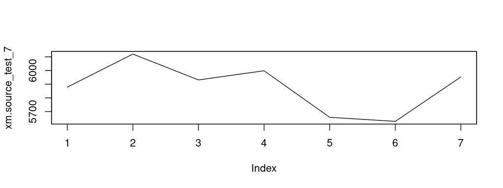

```r
plot(xm.source_test_7)
```

```r
#Les 7 bonnes prédictions avec lag
LAG=30
xm.source_test_7_lag <- zoo(dt[[2]])
desaison_test_7_lag <- xm.source_test_7_lag-lag(xm.source_test_7_lag,-LAG)
desaison_test_7_lag <- desaison_test_7_lag[523:530]
desaison_test_7_lag
```

```
##        553        554        555        556        557        558        559
## -862.49682 -873.01448 -625.70591   54.66877  464.16430  284.22069  149.72063
##        560
##  613.84652
```

```r
summary(desaison_test_7_lag)
```

```
##      Index       desaison_test_7_lag
##  Min.   :553.0   Min.   :-873.01
##  1st Qu.:554.8   1st Qu.:-684.90
##  Median :556.5   Median : 102.19
##  Mean   :556.5   Mean   : -99.32
##  3rd Qu.:558.2   3rd Qu.: 329.21
##  Max.   :560.0   Max.   : 613.85
```

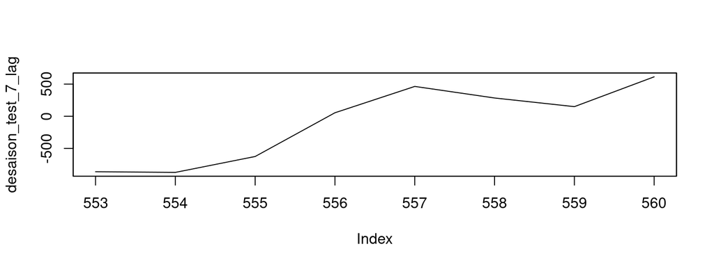

```r
plot(desaison_test_7_lag)
```

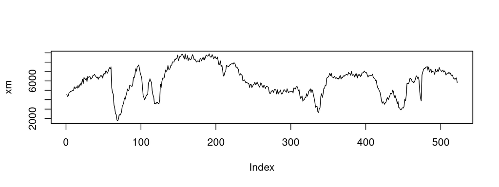

```r
#On met l'échantillon de train dans le format zoo et on plot:
xm.source <- zoo(dt_train[[2]])
xm.source_vrai <- zoo(dt[[2]])
xm <- xm.source
plot(xm)
```

```r
#Test de racine unitaire : Augmented Dickey-Füller
adf <- adfTest(xm, lag=0, type="nc") #
adf
```

```
##
## Title:
##  Augmented Dickey-Fuller Test
##
## Test Results:
##   PARAMETER:
##     Lag Order: 0
##   STATISTIC:
##     Dickey-Fuller: -0.4973
##   P VALUE:
##     0.4578
##
## Description:
##  Mon May  1 09:15:14 2023 by user: onyxia
```

```r
#Souhait: <0.05 H0 : rho =1
#Il y a une racine unitaire
```

#### 4.2.6.2 Une première approche avec un auto_arima sur la série brute

```r
#Une première approche avec une fonction qui exhibe de manière "black-box" le modèle ARIMA
fit <- auto.arima(xm)

dt_arima <- copy(dt)
for (i in (1:dim(dt_arima)[1])) {
  dt_arima[i,2] <- NaN

}
for (i in (1:length(as.numeric(forecast(fit,h=20)$mean)))) {
  dt_arima[518 +i,2] <- as.numeric(forecast(fit,h=20)$mean)[[i]]

}
names(dt_arima)[names(dt_arima) == 'y'] <- 'y_arima'
```

```r
Graph <- cbind(dt[dt$date >= "2022-12-15" & dt$date <= "2023-02-01", ][,-3], dt_arima[dt_arima$date >= "2022-12-15" & dt_arima$date <= "2023-02-01", ][,-3])
dygraph(Graph, main = "Prévision VS Labels modèle Black-Box")%>%
  dySeries("y", label = "Label") %>%
  dySeries("y_arima", label = "Prev")
```

[interactive chart not shown]

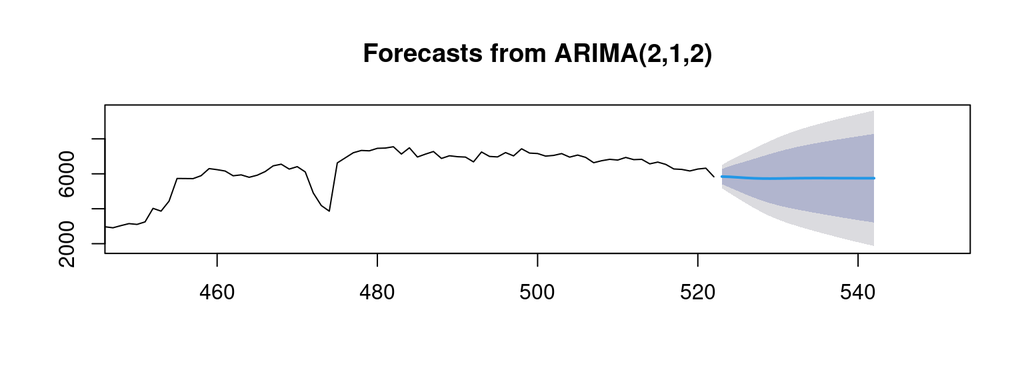

```r
plot(forecast(fit,h=20),xlim = c(450, 550))
```

```r
#Le modèle ainsi trouvé : c'est plus que critiquable !
fit
```

```
## Series: xm
## ARIMA(2,1,2)
##
## Coefficients:
##          ar1      ar2      ma1     ma2
##       1.3631  -0.6169  -1.3436  0.6845
## s.e.  0.2321   0.1761   0.2070  0.1325
##
## sigma^2 = 114212:  log likelihood = -3771.06
## AIC=7552.12   AICc=7552.24   BIC=7573.4
```

```r
rmse_init <- get_rmse(y_true = xm.source_test_7,
                      y_prev = as.numeric(forecast(fit,h=7)$mean))
rmse_init
```

```
## [1] 180.8209
```

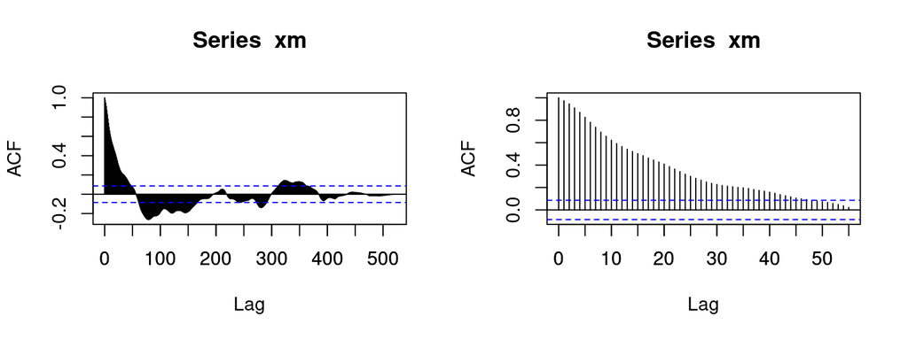

```r
#Autocorrélation de notre série:
par(mfrow=c(1,2)) #
acf(xm, lag.max = 600) #
axis(side=1,at=seq(0,600,50)) #
acf(xm, lag.max = 55) #
axis(side=1,at=seq(0,55,5)) #
```

```r
#On prend q = 50
```

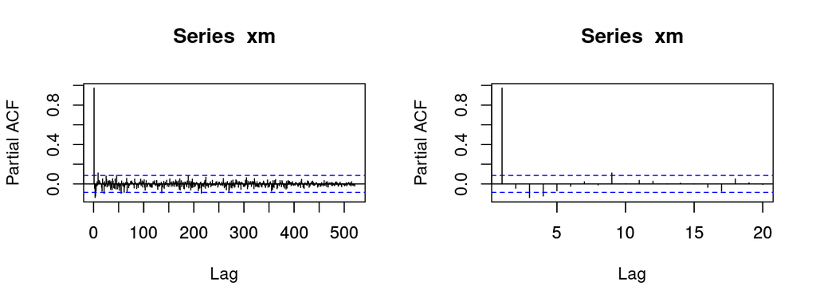

```r
#Autocorrélation partielle de notre série
par(mfrow=c(1,2)) #
pacf(xm, lag.max = 600) #
axis(side=1,at=seq(0,600,50))
pacf(xm, lag.max = 20) #
axis(side=1,at=seq(0,20,5))
```

```r
#On prend p=4
```

#### 4.2.6.3 Une seconde approche avec un auto_arima sur la série laggée de 30 jours

```r
#On essaie de soustraire l'effet mensuel
LAG=30
desaison <- xm-lag(xm,-LAG) #
desaison <- desaison - mean(desaison)
summary(desaison)
```

```
##      Index          desaison
##  Min.   : 31.0   Min.   :-4972.4
##  1st Qu.:153.8   1st Qu.:-1216.7
##  Median :276.5   Median : -205.6
##  Mean   :276.5   Mean   :    0.0
##  3rd Qu.:399.2   3rd Qu.: 1142.7
##  Max.   :522.0   Max.   : 5433.1
```

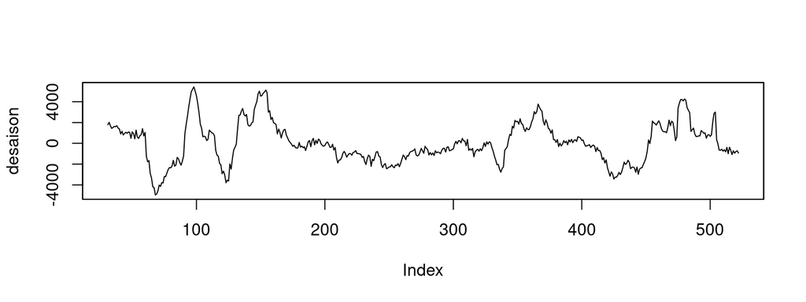

```r
plot(desaison)
```

```r
adf <- adfTest(desaison, lag=0, type="nc") #
adf
```

```
##
## Title:
##  Augmented Dickey-Fuller Test
##
## Test Results:
##   PARAMETER:
##     Lag Order: 0
##   STATISTIC:
##     Dickey-Fuller: -2.951
##   P VALUE:
##     0.01
##
## Description:
##  Mon May  1 09:15:15 2023 by user: onyxia
```

```r
#Souhait: <0.05 H0 : rho =1
#Il n'y a plus une racine unitaire
```

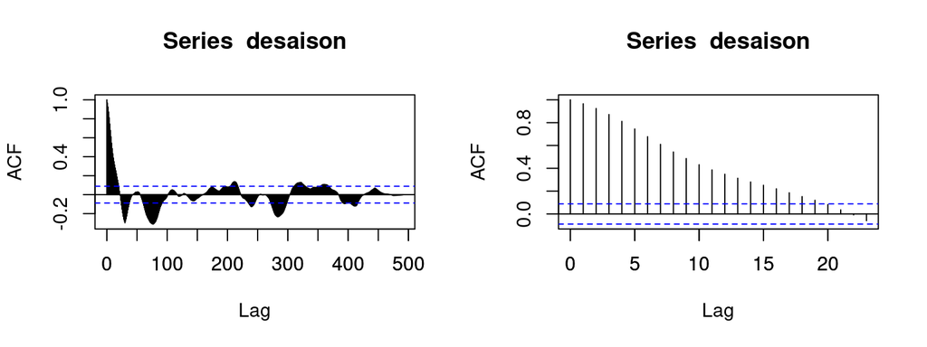

```r
#Autocorrélation de notre série avec lag:
par(mfrow=c(1,2)) #
acf(desaison, lag.max = 600) #
axis(side=1,at=seq(0,600,50)) #
acf(desaison, lag.max = 23) #
axis(side=1,at=seq(0,23,5)) #
```

```r
#On prend q=20
```

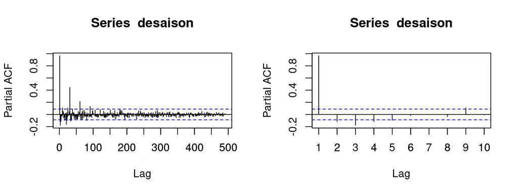

```r
#Autocorrélation partielle de notre série
par(mfrow=c(1,2)) #
pacf(desaison, lag.max = 600) #
axis(side=1,at=seq(0,600,50))
pacf(desaison, lag.max = 10) #
axis(side=1,at=seq(0,10,1))
```

```r
#On prend p=5
```

```r
#Modèle "Black-Box" sur cette série sans effet mensuel :
#Une première approche avec une fonction qui exhibe de manière "black-box" le modèle ARIMA
fit <- auto.arima(desaison)
xm.source_vrai <- zoo(dt[[2]])
desaison_vrai <- xm.source_vrai-lag(xm.source_vrai,-LAG) #

dt_arima <- copy(dt)
for (i in (1:dim(dt_arima)[1])) {
  dt_arima[i,2] <- NaN

}
for (i in (1:length(as.numeric(forecast(fit,h=20)$mean)))) {
  dt_arima[518 +i,2] <- as.numeric(forecast(fit,h=20)$mean)[[i]]

}
names(dt_arima)[names(dt_arima) == 'y'] <- 'y_arima'

dt_lag <-copy(dt)
for (i in (1:dim(dt_lag)[1])) {
  dt_lag[i,2] <- desaison_vrai[i]

}
```

```r
Graph <- cbind(dt_lag[dt_lag$date >= "2022-12-15" & dt_lag$date <= "2023-02-01", ][,-3], dt_arima[dt_arima$date >= "2022-12-15" & dt_arima$date <= "2023-02-01", ][,-3])
dygraph(Graph, main = paste("Prévision VS Labels modèle Black-Box avec LAG= ",toString(LAG)))%>%
  dySeries("y", label = "Label") %>%
  dySeries("y_arima", label = "Prev")
```

[interactive chart not shown]

```r
fit
```

```
## Series: desaison
## ARIMA(2,0,2) with zero mean
##
## Coefficients:
##          ar1      ar2      ma1     ma2
##       1.7248  -0.7488  -0.7076  0.1357
## s.e.  0.0763   0.0731   0.0856  0.0496
##
## sigma^2 = 227147:  log likelihood = -3731.58
## AIC=7473.16   AICc=7473.28   BIC=7494.15
```

```r
rmse_init <- get_rmse(y_true = desaison_test_7_lag,
                      y_prev = as.numeric(forecast(fit,h=7)$mean))
rmse_init
```

```
## [1] 841.6011
```

#### 4.2.6.4 Test de Stationnarité de la série brute/laggée

```r
#### Q4 ####
#Hypothèse nulle : la série a une racine sur le cercle unité / H1: Stationarité
pp.test(xm) #
```

```
##
##  Phillips-Perron Unit Root Test
##
## data:  xm
## Dickey-Fuller Z(alpha) = -20.543, Truncation lag parameter = 6, p-value
## = 0.06408
## alternative hypothesis: stationary
```

```r
#On veut une p-valeur inférieure à 0.05 : ce n'est pas le cas avec la série initiale
```

```r
#Hypothèse nulle : la série a une racine sur le cercle unité / H1: Stationarité
pp.test(desaison)
```

```
##
##  Phillips-Perron Unit Root Test
##
## data:  desaison
## Dickey-Fuller Z(alpha) = -27.198, Truncation lag parameter = 5, p-value
## = 0.01617
## alternative hypothesis: stationary
```

```r
#On veut une p-valeur inférieure à 0.05 : c'est le cas avec la série laggée
```

#### 4.2.6.5 Essais de modèle ARIMA à la main

```r
#On teste un modèle arima :
arima5_0_20 <- arima(desaison,c(5,0,20)) #
arima5_0_20
```

```
##
## Call:
## arima(x = desaison, order = c(5, 0, 20))
##
## Coefficients:
##           ar1     ar2      ar3     ar4     ar5     ma1     ma2     ma3     ma4
##       -0.3681  0.2565  -0.3179  0.1703  0.6817  1.4410  1.3764  1.8929  1.7636
## s.e.   0.0630  0.0716   0.0601  0.0607  0.0485  0.0759  0.1444  0.1967  0.2788
##          ma5     ma6     ma7     ma8     ma9    ma10     ma11     ma12     ma13
##       0.9694  0.8725  0.7196  0.5064  0.3896  0.3058  -0.0232  -0.1007  -0.2014
## s.e.  0.3398  0.3570  0.3604  0.3460  0.3163  0.2780   0.2360   0.1866   0.1485
##          ma14    ma15    ma16    ma17    ma18    ma19    ma20  intercept
##       -0.2564  0.2764  0.6875  0.6124  0.9145  0.7571  0.3002    13.9661
## s.e.   0.1370  0.1493  0.1711  0.1694  0.1322  0.1075  0.0721   449.3181
##
## sigma^2 estimated as 172471:  log likelihood = -3676.82,  aic = 7407.63
```